# R Notebook

```r
library(ggplot2)
library(tibble)
library(boot)
library(dplyr)
data <- read_csv("C:/Users/User/Downloads/data_analitycs/Diabetes-study/lab1-EDA/data/diabetic_data.csv")
str(data, give.attr = FALSE)
```

```
spc_tbl_ [101,766 × 50] (S3: spec_tbl_df/tbl_df/tbl/data.frame)
 $ encounter_id            : num [1:101766] 2278392 149190 64410 500364 16680 ...
 $ patient_nbr             : num [1:101766] 8222157 55629189 86047875 82442376 42519267 ...
 $ race                    : chr [1:101766] "Caucasian" "Caucasian" "AfricanAmerican" "Caucasian" ...
 $ gender                  : chr [1:101766] "Female" "Female" "Female" "Male" ...
 $ age                     : chr [1:101766] "[0-10)" "[10-20)" "[20-30)" "[30-40)" ...
 $ weight                  : chr [1:101766] "?" "?" "?" "?" ...
 $ admission_type_id       : num [1:101766] 6 1 1 1 1 2 3 1 2 3 ...
 $ discharge_disposition_id: num [1:101766] 25 1 1 1 1 1 1 1 1 3 ...
 $ admission_source_id     : num [1:101766] 1 7 7 7 7 2 2 7 4 4 ...
 $ time_in_hospital        : num [1:101766] 1 3 2 2 1 3 4 5 13 12 ...
 $ payer_code              : chr [1:101766] "?" "?" "?" "?" ...
 $ medical_specialty       : chr [1:101766] "Pediatrics-Endocrinology" "?" "?" "?" ...
 $ num_lab_procedures      : num [1:101766] 41 59 11 44 51 31 70 73 68 33 ...
 $ num_procedures          : num [1:101766] 0 0 5 1 0 6 1 0 2 3 ...
```

[output cut: 36 more lines]

```r
options(scipen = 999)
```

1. Середнє number_diagnoses
- коротка статистика по змінній

```r
number_diagnoses_mean <- mean(data$number_diagnoses, na.rm = TRUE)
number_diagnoses_median <- median(data$number_diagnoses, na.rm = TRUE)
number_diagnoses_sd <- sd(data$number_diagnoses, na.rm = TRUE)
number_diagnoses_n <- sum(!is.na(data$number_diagnoses))
number_diagnoses_min_value <- min(data$number_diagnoses, na.rm = TRUE)
number_diagnoses_max_value <- max(data$number_diagnoses, na.rm = TRUE)


summary_table <- data.frame(
  Показник = c("Середнє", "Медіана", "Стандартне відхилення", "Кількість спостережень", "Мінімум", "Максимум"),
  Значення = c(number_diagnoses_mean, number_diagnoses_median, number_diagnoses_sd, number_diagnoses_n, number_diagnoses_min_value, number_diagnoses_max_value)
)

print(summary_table)
```

| Показник | Значення |
| --- | --- |
| Середнє | 7.422607 |
| Медіана | 8.000000 |
| Стандартне відхилення | 1.933600 |
| Кількість спостережень | 101766.000000 |
| Мінімум | 1.000000 |
| Максимум | 16.000000 |

*будуємо боксплот

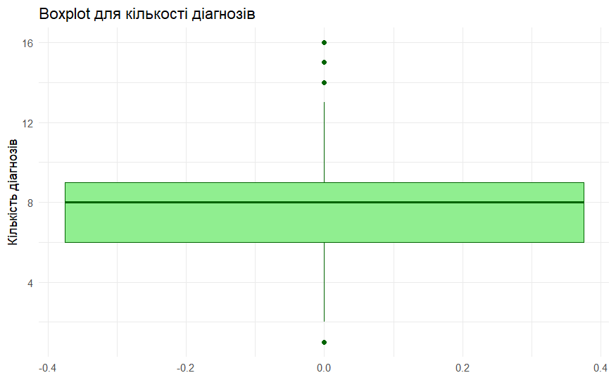

```r
ggplot(data, aes(y = number_diagnoses)) +
  geom_boxplot(fill = "lightgreen", color = "darkgreen") +
  labs(title = "Boxplot для кількості діагнозів", y = "Кількість діагнозів") +
  theme_minimal()
```

*перевірка номральності розподілу

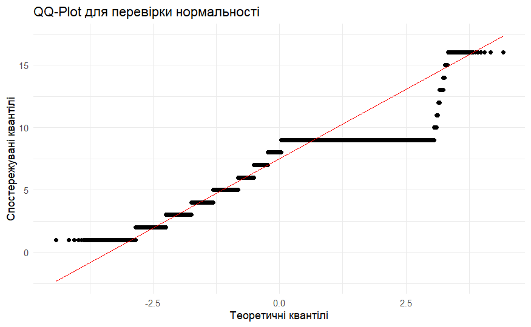

```r
ggplot(data, aes(sample = number_diagnoses)) +
  stat_qq() +
  stat_qq_line(color = "red") +
  labs(title = "QQ-Plot для перевірки нормальності",
       x = "Теоретичні квантілі",
       y = "Спостережувані квантілі") +
  theme_minimal()
```

*сам інтервал

```r
number_diagnoses_se = number_diagnoses_sd / sqrt(number_diagnoses_n)

t_crit <- qt(0.975, df = number_diagnoses_n - 1)

lower <- number_diagnoses_mean - t_crit * number_diagnoses_se
upper <- number_diagnoses_mean + t_crit * number_diagnoses_se

summary_table <- tibble(number_diagnoses_mean, number_diagnoses_sd, number_diagnoses_n, lower, upper)

print(summary_table)
```

| number_diagnoses_mean | number_diagnoses_sd | number_diagnoses_n | lower | upper |
| --- | --- | --- | --- | --- |
| 7.422607 | 1.9336 | 101766 | 7.410727 | 7.434487 |

```r
NA
```

2. кореляція між num_medications та num_lab_procedures (boot)

*Scatterplot + LOESS + norm двох змінних

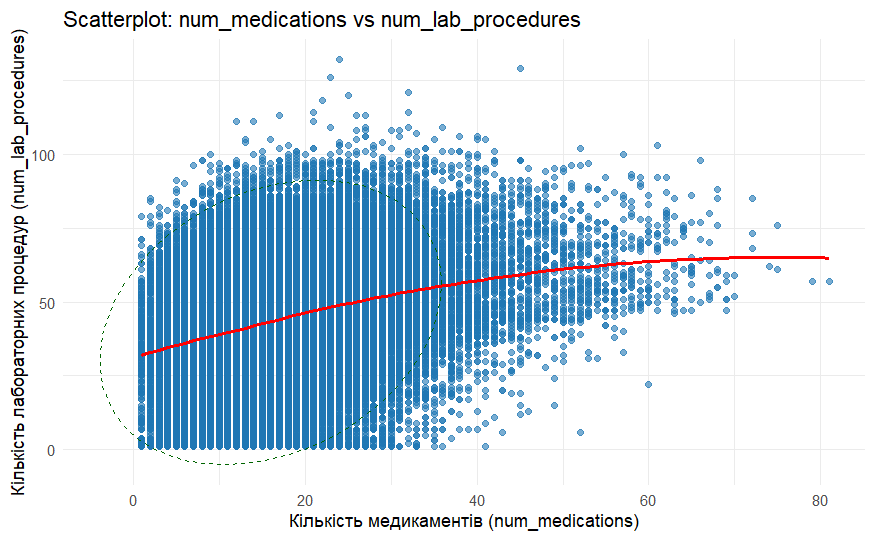

```r
library(ggpubr)  # для stat_cor
# Припустимо, у вас вже є датафрейм `data`
ggplot(data, aes(x = num_medications, y = num_lab_procedures)) +
  geom_point(alpha = 0.6, color = "#1f77b4") +  # точки
  geom_smooth(method = "loess", se = FALSE, color = "red", size = 1) +  # LOESS-крива
  stat_ellipse(type = "norm", linetype = 2, color = "darkgreen") +  # еліпс
  theme_minimal() +
  labs(
    x = "Кількість медикаментів (num_medications)",
    y = "Кількість лабораторних процедур (num_lab_procedures)",
    title = "Scatterplot: num_medications vs num_lab_procedures"
  )
```

*рахуємо кореляцію

```r
cor.test(data$num_medications, data$num_lab_procedures, method = "spearman")
```

```
    Spearman's rank correlation rho

data:  data$num_medications and data$num_lab_procedures
S = 131453194986667, p-value < 0.00000000000000022
alternative hypothesis: true rho is not equal to 0
sample estimates:
      rho
0.2516336
```

*рахуємо інтервали

```r
# Функція для обчислення кореляції Спірмана

spearman_cor_stud <- function(data, indices) {
  d <- data[indices, ]

  rho_hat <- cor(d$num_medications, d$num_lab_procedures, method = "spearman")

  # Внутрішній бутстреп для оцінки стандартної похибки
  inner_boot <- boot(
    data = d,
    statistic = function(inner_data, i) {
      cor(inner_data[i, "num_medications"], inner_data[i, "num_lab_procedures"], method = "spearman")
    },
    R = 100
  )

  se_hat <- sd(inner_boot$t, na.rm = TRUE)

  return(c(rho_hat, se_hat))
}
```

```r
set.seed(123)
data_small <- data[sample(nrow(data), 10000), ]

boot_out <- boot(
  data = data_small,
  statistic = spearman_cor_stud,
  R = 1000
)


## 4. доверительные интервалы
ci_perc2  <- boot.ci(boot_out, type = "perc")   # Percentile
ci_basic2 <- boot.ci(boot_out, type = "basic")  # Basic
ci_stud  <- boot.ci(boot_out, type = "stud")   # Studentized
```

```r
print(ci_stud)
```

```
BOOTSTRAP CONFIDENCE INTERVAL CALCULATIONS
Based on 1000 bootstrap replicates

CALL :
boot.ci(boot.out = boot_out, type = "stud")

Intervals :
Level    Studentized
95%   ( 0.2345,  0.2706 )
Calculations and Intervals on Original Scale
```

*виводимо таблицю інтервалів

```r
ci_table <- tibble::tibble(
  Type = c("Percentile", "Basic", "Studentized"),
  Lower = c(
    ci_perc2$perc[4],
    ci_basic2$basic[4],
    ci_stud$student[4]
  ),
  Upper = c(
    ci_perc2$perc[5],
    ci_basic2$basic[5],
    ci_stud$student[5]
  )
)

print(ci_table)
```

| Type | Lower | Upper |
| --- | --- | --- |
| Percentile | 0.2352642 | 0.2718570 |
| Basic | 0.2343665 | 0.2709593 |
| Studentized | 0.2344821 | 0.2705929 |

```r
NA
```

```r
ci <- ci_perc2$perc[4:5]
df <- data.frame(rho = boot_corr)
```

[output not shown]

- перевірка гіпотези тестом Волда

```r
rho_hat <- mean(boot_out$t[,1], na.rm = TRUE)

# Стандартна похибка
se_hat <- sd(boot_out$t[,1], na.rm = TRUE)

# Тестова статистика
z <- rho_hat / se_hat

# P-value (двосторонній тест)
p_value <- 2 * (1 - pnorm(abs(z)))

alpha <- 0.05
z_crit <- qnorm(1 - alpha / 2)

cat("Wald-тест: z =", round(z, 3), ", p =", format.pval(p_value, digits = 5), ", z_crit = ", round(z_crit,3))
```

```
Wald-тест: z = 27.476 , p = < 0.000000000000000222 , z_crit =  1.96
```

3. Дослвідження різниці середньої кількості амбулаторних відвідувань між чоловіками та жінками

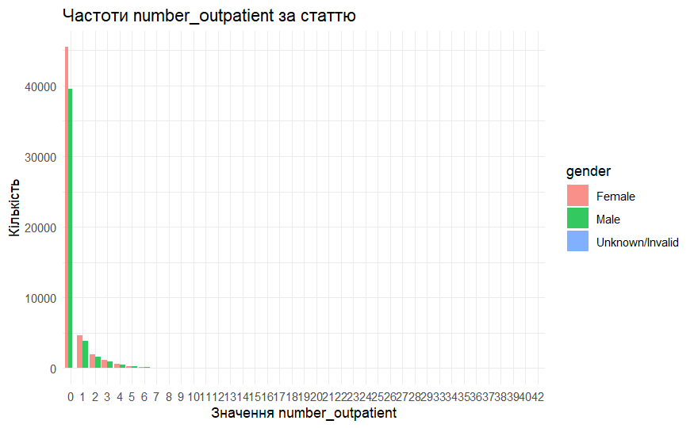

```r
data %>%
  count(gender, number_outpatient) %>%
  ggplot(aes(x = factor(number_outpatient), y = n, fill = gender)) +
  geom_col(position = "dodge", alpha = 0.8) +
  labs(title = "Частоти number_outpatient за статтю",
       x = "Значення number_outpatient",
       y = "Кількість") +
  theme_minimal()
```

*перевірка на гомогенність дисперсій

```r
fligner.test(number_outpatient ~ gender, data = data)
```

```
    Fligner-Killeen test of homogeneity of variances

data:  number_outpatient by gender
Fligner-Killeen:med chi-squared = 18.767, df = 2, p-value = 0.00008411
```

*побудова інтервалу

```r
# Групи
x1 <- data$number_outpatient[data$gender == "Female"]
x2 <- data$number_outpatient[data$gender == "Male"]

# Розміри вибірок
n1 <- length(x1)
n2 <- length(x2)

# Середні значення
mean1 <- mean(x1, na.rm = TRUE)
mean2 <- mean(x2, na.rm = TRUE)

# Вибіркові дисперсії
s1_sq <- var(x1, na.rm = TRUE)
s2_sq <- var(x2, na.rm = TRUE)

# Стандартна похибка
SE <- sqrt(s1_sq / n1 + s2_sq / n2)

# Критичне значення z для 95% довірчого інтервалу
z <- qnorm(0.975)  # ≈ 1.96

# Межі інтервалу
diff <- mean1 - mean2
CI_lower <- diff - z * SE
CI_upper <- diff + z * SE

# Результат
cat("95% Довірчий інтервал для різниці середніх (z):\n")
```

```
95% Довірчий інтервал для різниці середніх (z):
```

```r
cat(sprintf("[%.3f, %.3f]\n", CI_lower, CI_upper))
```

```
[0.014, 0.045]
```

*проводимо тест волда

```r
# Тестова статистика Вальда (z)
z_stat <- (mean1 - mean2) / SE

# P-value для двостороннього тесту
p_value <- 2 * (1 - pnorm(abs(z_stat)))

# Вивід
cat("Wald тест для різниці середніх:\n")
```

```
Wald тест для різниці середніх:
```

```r
cat(sprintf("z = %.3f\n", z_stat))
```

```
z = 3.669
```

```r
cat(sprintf("p-value = %.5f\n", p_value))
```

```
p-value = 0.00024
```

Довірчий інтервал для частки жінок

```r
n_fem <- sum(data$gender == "Female", na.rm = TRUE)
n_patients <- sum(data$gender %in% c("Female", "Male"), na.rm = TRUE)
p_hat <- n_fem / n_patients
se <- sqrt(p_hat * (1 - p_hat) / n_patients)
z <- qnorm(0.975)
ci <- p_hat + c(-1, 1) * z * se

cat("95% Довірчий інтервал для частки жінок:\n")
```

```
95% Довірчий інтервал для частки жінок:
```

```r
cat("[",ci,"]")
```

```
[ 0.5345388 0.5406654 ]
```

Довірчий інтервал для частки чоловіків

```r
x <- sum(data$gender == "Male", na.rm = TRUE)
n <- sum(data$gender %in% c("Female", "Male"), na.rm = TRUE)
p_hat <- x / n
se <- sqrt(p_hat * (1 - p_hat) / n)
z <- qnorm(0.975)
ci_prop <- p_hat + c(-1, 1) * z * se
round(ci_prop, 3)
```

```
[1] 0.459 0.465
```

```r
cat("95% Довірчий інтервал для частки чоловіків:\n")
```

```
95% Довірчий інтервал для частки чоловіків:
```

```r
cat("[",ci_prop,"]")
```

```
[ 0.4593346 0.4654612 ]
```

Довірчий інтервал для середнього time_in_hospital

```r
x <- data$time_in_hospital
n <- length(x)
mean_x <- mean(x, na.rm = TRUE)
sd_x <- sd(x, na.rm = TRUE)
ci_mean <- mean_x + c(-1, 1) * z * sd_x / sqrt(n)
cat("95% Довірчий інтервал для для середнього time_in_hospital:\n")
```

```
95% Довірчий інтервал для для середнього time_in_hospital:
```

```r
cat("[",ci_mean,"]")
```

```
[ 4.377647 4.414327 ]
```

```r
cat(sd_x / sqrt(n))
```

```
0.009357475
```

Чи відрізняється середня тривалість госпіталізації між чоловіками та жінками?

```r
df_gender <- data %>% filter(gender %in% c("Female", "Male"))
x1 <- df_gender %>% filter(gender == "Female") %>% pull(time_in_hospital)
x2 <- df_gender %>% filter(gender == "Male") %>% pull(time_in_hospital)
n1 <- length(x1); n2 <- length(x2)
m1 <- mean(x1); m2 <- mean(x2)
s1 <- sd(x1); s2 <- sd(x2)
W <- (m1 - m2) / sqrt(s1^2 / n1 + s2^2 / n2)
p_value <- 2 * (1 - pnorm(abs(W)))


cat("Wald тест для різниці середніх:\n")
```

```
Wald тест для різниці середніх:
```

```r
cat(sprintf("W = %.3f\n", z_stat))
```

```
W = 3.669
```

```r
cat(sprintf("p-value = %.5f\n", p_value))
```

```
p-value = 0.00000
```

*боксплот побудуємо

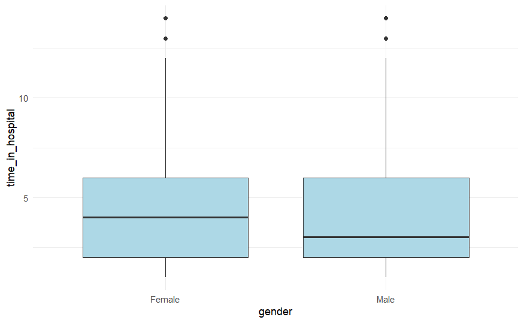

```r
ggplot(data %>% filter(gender %in% c("Female", "Male")),
       aes(x = gender, y = time_in_hospital)) +
  geom_boxplot(fill = "lightblue") +
  theme_minimal()
```

```r
female_sample <- df_gender %>% filter(gender == "Female") %>% pull(number_inpatient)
male_sample   <- df_gender %>% filter(gender == "Male") %>% pull(number_inpatient)
m1 <- mean(female_sample); m2 <- mean(male_sample)
s1 <- sd(female_sample); s2 <- sd(male_sample)
n1 <- length(female_sample); n2 <- length(male_sample)
W <- (m1 - m2) / sqrt(s1^2 / n1 + s2^2 / n2)
p_value <- 1 - pnorm(W)  # односторонній

cat("Односторонній тест Вальда для порівняння середніх :\n")
```

```
Односторонній тест Вальда для порівняння середніх :
```

```r
cat(sprintf("W = %.3f\n", z_stat))
```

```
W = 3.669
```

```r
cat(sprintf("p-value = %.5f\n", p_value))
```

```
p-value = 0.00000
```

H₀ (нульова гіпотеза)(середня кількість госпіталізацій у жінок не перевищує таку у чоловіків)

H₁ (альтернативна гіпотеза):(середня кількість госпіталізацій у жінок більша, ніж у чоловіків) Якщо p-value < 0.05 — відкидаємо H₀, визнаємо, що у жінок середня кількість госпіталізацій статистично значуще вища.

Чи частка жінок із ≥3 госпіталізаціями не перевищує частку чоловіків?

```r
p_fem <- mean(female_sample >= 3)
p_mal <- mean(male_sample >= 3)
n_fem <- length(female_sample); n_mal <- length(male_sample)
se_diff <- sqrt(p_fem*(1-p_fem)/n_fem + p_mal*(1-p_mal)/n_mal)
W <- (p_fem - p_mal) / se_diff
p_value <- 1 - pnorm(W)

cat(se_diff)
```

```
0.001592954
```

```r
cat("Wald тест :\n")
```

```
Wald тест :
```

```r
cat(sprintf("W = %.3f\n", z_stat))
```

```
W = 3.669
```

```r
cat(sprintf("p-value = %.5f\n", p_value))
```

```
p-value = 0.00383
```

H₀ (нульова гіпотеза):(частка жінок із ≥3 госпіталізаціями не перевищує частку чоловіків)

H₁ (альтернативна гіпотеза):(частка жінок із ≥3 госпіталізаціями більша, ніж у чоловіків) Якщо p-value < 0.05 — відкидаємо H₀, визнаємо, що серед жінок частка з ≥3 госпіталізаціями дійсно більша.

Довірчий інтервал для частки пацієнтів із повторною госпіталізацією (readmitted = ‘<30’)

```r
x <- sum(data$readmitted == "<30", na.rm = TRUE)
n <- sum(!is.na(data$readmitted))
p_hat_30 <- x / n
se <- sqrt(p_hat * (1 - p_hat_30) / n)
z <- qnorm(0.975)
ci_readm_30 <- p_hat_30 + c(-1, 1) * z * se
round(ci_readm, 3)
```

[output not shown]

Довірчий інтервал для частки пацієнтів із повторною госпіталізацією (readmitted = ‘>30’)

```r
x <- sum(data$readmitted == ">30", na.rm = TRUE)
n <- sum(!is.na(data$readmitted))
p_hat_30plus <- x / n
se <- sqrt(p_hat * (1 - p_hat_30plus) / n)
z <- qnorm(0.975)
ci_readm_30plus <- p_hat_30plus + c(-1, 1) * z * se
round(ci_readm, 3)
```

[output not shown]

Довірчий інтервал для частки пацієнтів із повторною госпіталізацією (readmitted = ‘NO’)

```r
x <- sum(data$readmitted == "NO", na.rm = TRUE)
n <- sum(!is.na(data$readmitted))
p_hat_NO <- x / n
se <- sqrt(p_hat * (1 - p_hat_NO) / n)
z <- qnorm(0.975)
ci_readm_NO <- p_hat_NO + c(-1, 1) * z * se
round(ci_readm, 3)
```

```
[1] 0.536 0.542
```

```r
ci_table <- data.frame(
  category = c("<30", ">30", "NO"),
  CI_lower = c(ci_readm_30[1], ci_readm_30plus[1], ci_readm_NO[1]),
  CI_upper = c(ci_readm_30[2], ci_readm_30plus[2], ci_readm_NO[2])
)

# Додай p_hat, якщо зберігав окремо:
ci_table$p_hat <- c(p_hat_30, p_hat_30plus, p_hat_NO)

ci_table
```

| category | CI_lower | CI_upper | p_hat |
| --- | --- | --- | --- |
| <30 | 0.1073472 | 0.1158512 | 0.1115992 |
| >30 | 0.3456427 | 0.3529207 | 0.3492817 |
| NO | 0.5360566 | 0.5421817 | 0.5391192 |

```r
NA
```

Гіпотеза:

H₀: Частка ≤ 10%

H₁: Частка > 10% (одностороння) Тест Волда:

```r
W <- (p_hat_NO - 0.10) / se
p_value <- 1 - pnorm(W)

cat("Wald тест :\n")
cat(sprintf("W = %.3f\n", W))
cat(sprintf("p-value = %.5f\n", p_value))

se
```

[output not shown]

Довірчий інтервал для коефіцієнта кореляції Пірсона між time_in_hospital і number_diagnoses (idk висновок, придуймайте, або не додавайте в лаб2)

```r
cor_pearson <- cor(data$time_in_hospital, data$number_diagnoses, method = "pearson", use = "complete.obs")
n_corr <- sum(complete.cases(data$time_in_hospital, data$number_diagnoses))
z_r <- 0.5 * log((1 + cor_pearson) / (1 - cor_pearson))
se_z <- 1 / sqrt(n_corr - 3)
ci_z <- z_r + c(-1, 1) * z * se_z
ci_r <- (exp(2 * ci_z) - 1) / (exp(2 * ci_z) + 1)
cat("95% Довірчий інтервал для для кореляції:\n")
```

```
95% Довірчий інтервал для для кореляції:
```

```r
cat("[",ci_r,"]")
```

```
[ 0.2143323 0.2260245 ]
```

```r
cat("SE= ", se)
```

```
SE=  0.001562555
```

Порівняння середньої кількості діагнозів у різних вікових групах Пояснення: Перевірка, чи середня кількість діагнозів у групі 70–80 років більша, ніж у групі 40–50 років.

```r
x1 <- data %>% filter(age == '[70-80)') %>% pull(number_diagnoses)
x2 <- data %>% filter(age == '[40-50)') %>% pull(number_diagnoses)
m1 <- mean(x1, na.rm = TRUE); m2 <- mean(x2, na.rm = TRUE)
s1 <- sd(x1, na.rm = TRUE); s2 <- sd(x2, na.rm = TRUE)
n1 <- length(x1); n2 <- length(x2)
W <- (m1 - m2) / sqrt(s1^2/n1 + s2^2/n2)
p_value <- 1 - pnorm(W)  # односторонній тест

cat("Wald тест :\n")
```

```
Wald тест :
```

```r
round(c("W" = W, "p-value" = p_value), 4)
```

```
      W p-value
29.6501  0.0000
```

Чи відрізняється медіана тривалості госпіталізації між екстреною та плановою госпіталізацією?

```r
emerg <- data %>%
  filter(admission_type_id == 1) %>%
  pull(time_in_hospital)

plan <- data %>%
  filter(admission_type_id == 3) %>%
  pull(time_in_hospital)
# Функція для бутстрепу різниці медіан
boot_med_diff <- function(data, indices) {
  emerg_boot <- sample(emerg, length(emerg), replace = TRUE)
  plan_boot <- sample(plan, length(plan), replace = TRUE)
  return(median(emerg_boot, na.rm = TRUE) - median(plan_boot, na.rm = TRUE))
}
boot_diff <- boot(data = 1:length(emerg), statistic = boot_med_diff, R = 2000)
boot.ci(boot_diff, type = c("perc", "bca"))
```

```
BOOTSTRAP CONFIDENCE INTERVAL CALCULATIONS
Based on 2000 bootstrap replicates

CALL :
boot.ci(boot.out = boot_diff, type = c("perc", "bca"))

Intervals :
Level     Percentile            BCa
95%   ( 0,  1 )   ( 0,  1 )
Calculations and Intervals on Original Scale
```

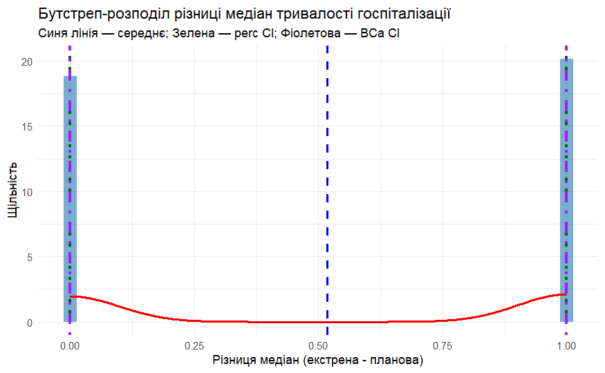

```r
# 1. Витягнути бутстреп-оцінки
boot_dist <- boot_diff$t[, 1]  # Вектор з різницями медіан

# 2. Отримати довірчі інтервали
ci <- boot.ci(boot_diff, type = c("perc", "bca"))

# 3. Витягнути межі інтервалів
ci_perc <- ci$percent[4:5]  # нижня і верхня межа percent CI
ci_bca  <- ci$bca[4:5]      # нижня і верхня межа BCa CI

# 4. Побудова графіка
df <- data.frame(diff = boot_dist)

ggplot(df, aes(x = diff)) +
  geom_histogram(aes(y = ..density..), bins = 40, fill = "#1f77b4", alpha = 0.6) +
  geom_density(color = "red", size = 1) +
  geom_vline(xintercept = mean(boot_dist), color = "blue", linetype = "dashed", size = 1) +
  geom_vline(xintercept = ci_perc, color = "darkgreen", linetype = "dotted", size = 1.2) +
  geom_vline(xintercept = ci_bca, color = "purple", linetype = "dotdash", size = 1.2) +
  labs(
    title = "Бутстреп-розподіл різниці медіан тривалості госпіталізації",
    x = "Різниця медіан (екстрена - планова)",
    y = "Щільність",
    subtitle = paste0("Синя лінія — середнє; Зелена — perc CI; Фіолетова — BCa CI")
  ) +
  theme_minimal()
```